# ODOT crashes for Eugene and selected cities

## Overview

The big question is: Why are fatalities going up? Visualizations suggest a few things:

1. Eugene is small enough, and its fatality rate low enough, that its fatality rate is subject to statistical noise year over year.
2. Whatever real increase is happening is following the same trend that state and national trends are.

This is not a hopeful result. It implies that as far as traffic fatalities, we may not have much local control over trends.

However, our overall crash, injury, and fatality rates remain lower than many other cities. It is possible we are doing the right thing as far as absolute rates - but we may not be able to buck the trend in direction, due to vehicle size and driver distractions.

## Methodology

Eugene, comparable cities in Oregon, Oregon as a whole, and the US are compared for crashes, injuries, and fatalities.

Cities of similar size to Eugene that are suburbs of Portland are ignored, as being a 'different kind of beast'.

Sources:

- [ODOT Crash Statistics](https://www.oregon.gov/ODOT/Data/Pages/Crash.aspx)
- [Oregon GEOHub City Limits](https://geohub.oregon.gov/datasets/87ba24bbe79d47c3950d4e9d1ff0770c_220/explore)
- [NHTSA FARS Tables](https://www-fars.nhtsa.dot.gov/Main/index.aspx)
- [PSU Population Research Center](https://www.pdx.edu/population-research/)
- [FBI Crime Data Explorer](https://cde.ucr.cjis.gov/LATEST/webapp/#/pages/explorer/crime/crime-trend)

## Crashes

Non-fatality crash data is suspect on a national level due to varying reporting policies, so US-all is not included.

Reported crashes show a similar pattern across the various cities, and Oregon as a whole. Crashes seem to be declining from 2016 to 2019, drop precipitously in 2020, then rise again over the next few years, but mostly not to pre-pandemic levels.

Eugene's numbers are low compared to other cities and to Oregon. (Albany and Corvallis are lower still, but we run out of visually distinguishable colors.) It is impossible to know if this is due to reporting rate or better safety, but the shape over time follows that of other cities.

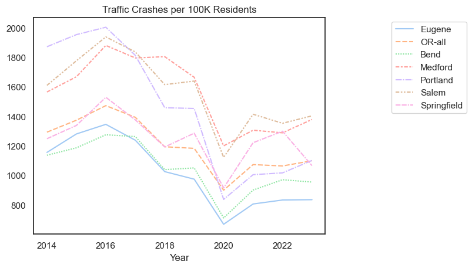

## Injuries

We skip US-all for injuries for similar reasons to crashes.

Reported injuries look very similar to reported crashes, with the same decline, steep drop in 2020, and partial rebound in years since.

Again, Eugene is near the bottom, and again, it is impossible to know how much of this is due to reporting rates vs safety.

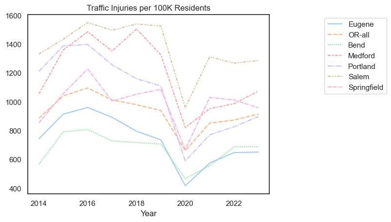

# Traffic Fatalities

Traffic Fatalities are likely to be more consistently reported than non-fatal crashes, so we include US federal data for this plot.

Since traffic fatalities occur in small numbers locally, the numbers are more subject to statistical noise when measured in smaller cities. This is reflected in the plot, which shows big spikes and dips yearly for cities smaller than Portland, but not so much for Portland, Oregon, and the US.

We also include 2024 data in the plot, although it is preliminary. This means that Oregon and the US show large dropoffs in 2024, which should not be trusted.

Eugene's numbers show a similar shape to Oregon and the US: flat until 2020, followed by a multi-year spike.

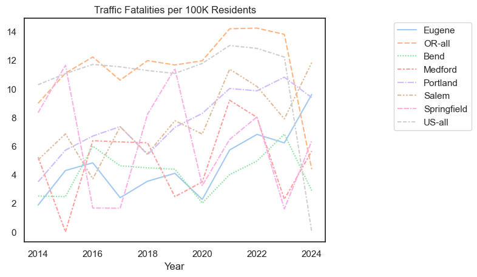

## Traffic Fatalities and Homicides

Finally, we compare traffic fatalities to homicides, just in Eugene. We see that cars violence is the more frequent cause of violent death than homicide in every single year since at least 2014.

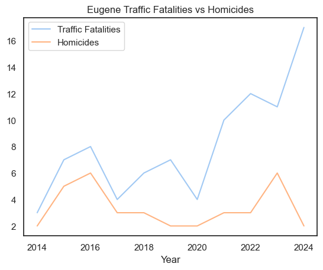